# DGE Tutorial

Pelle S. van Hilst

2024-03-28

This is based on a tutorial by Rachel Stewart, rewriting by me to help me understand it better.

Set working directory

```r
rm(list=ls())
setwd("D:/Master_thesis/How_to_unix_R/DGE_analysis_tutorial/RNAseq_analysis")
getwd()
```

```
## [1] "D:/Master_thesis/How_to_unix_R/DGE_analysis_tutorial/RNAseq_analysis"
```

Load the packages

```r
myLib <- as.vector(c("DESeq2","topGO", "magrittr", "dplyr","tidyr",
                     "readr", "tibble", "ggplot2", "forcats", "RColorBrewer"))
lapply(myLib,library, character.only=TRUE )
```

[output not shown]

[output cut: 94 more lines]

Read sample data using R package readr

```r
Pcal_sampledata <- read_tsv("Pcal_sampledata.tsv",
                            col_types = c("ccfff"))
# here we specify the column types using a condensed string, one letter for each column.
# 'c' stands for character, 'f' for factor
```

Lets look at the data

```r
print(n=27, Pcal_sampledata)
```

```
## # A tibble: 27 × 5
##    sampleName     fileName                      condition family conditionFamily
##    <chr>          <chr>                         <fct>     <fct>  <fct>
##  1 Pca_Ribes_rep1 Pca_Ribes_rep1_geneCounts.txt Ribes     1      Ribes_1
##  2 Pca_Ribes_rep2 Pca_Ribes_rep2_geneCounts.txt Ribes     1      Ribes_1
##  3 Pca_Ribes_rep3 Pca_Ribes_rep3_geneCounts.txt Ribes     1      Ribes_1
##  4 Pca_Ribes_rep4 Pca_Ribes_rep4_geneCounts.txt Ribes     2      Ribes_2
##  5 Pca_Ribes_rep5 Pca_Ribes_rep5_geneCounts.txt Ribes     2      Ribes_2
##  6 Pca_Ribes_rep6 Pca_Ribes_rep6_geneCounts.txt Ribes     2      Ribes_2
##  7 Pca_Ribes_rep7 Pca_Ribes_rep7_geneCounts.txt Ribes     3      Ribes_3
##  8 Pca_Ribes_rep8 Pca_Ribes_rep8_geneCounts.txt Ribes     3      Ribes_3
##  9 Pca_Ribes_rep9 Pca_Ribes_rep9_geneCounts.txt Ribes     3      Ribes_3
## 10 Pca_Salix_rep1 Pca_Salix_rep1_geneCounts.txt Salix     1      Salix_1
## 11 Pca_Salix_rep2 Pca_Salix_rep2_geneCounts.txt Salix     1      Salix_1
## 12 Pca_Salix_rep3 Pca_Salix_rep3_geneCounts.txt Salix     1      Salix_1
## 13 Pca_Salix_rep4 Pca_Salix_rep4_geneCounts.txt Salix     2      Salix_2
## 14 Pca_Salix_rep5 Pca_Salix_rep5_geneCounts.txt Salix     2      Salix_2
## 15 Pca_Salix_rep6 Pca_Salix_rep6_geneCounts.txt Salix     2      Salix_2
## 16 Pca_Salix_rep7 Pca_Salix_rep7_geneCounts.txt Salix     3      Salix_3
## 17 Pca_Salix_rep8 Pca_Salix_rep8_geneCounts.txt Salix     3      Salix_3
## 18 Pca_Salix_rep9 Pca_Salix_rep9_geneCounts.txt Salix     3      Salix_3
## 19 Pca_Udi_rep1   Pca_Udi_rep1_geneCounts.txt   Urtica    1      Urtica_1
## 20 Pca_Udi_rep2   Pca_Udi_rep2_geneCounts.txt   Urtica    1      Urtica_1
## 21 Pca_Udi_rep3   Pca_Udi_rep3_geneCounts.txt   Urtica    1      Urtica_1
## 22 Pca_Udi_rep4   Pca_Udi_rep4_geneCounts.txt   Urtica    2      Urtica_2
## 23 Pca_Udi_rep5   Pca_Udi_rep5_geneCounts.txt   Urtica    2      Urtica_2
## 24 Pca_Udi_rep6   Pca_Udi_rep6_geneCounts.txt   Urtica    2      Urtica_2
## 25 Pca_Udi_rep7   Pca_Udi_rep7_geneCounts.txt   Urtica    3      Urtica_3
## 26 Pca_Udi_rep8   Pca_Udi_rep8_geneCounts.txt   Urtica    3      Urtica_3
## 27 Pca_Udi_rep9   Pca_Udi_rep9_geneCounts.txt   Urtica    3      Urtica_3
```

Not a lot of samples per family

```r
table(Pcal_sampledata[3:4])
```

```
##          family
## condition 1 2 3
##    Ribes  3 3 3
##    Salix  3 3 3
##    Urtica 3 3 3
```

Only three per family and most DGE tools recommend at least 7 samples per group, so we will work on a species basis

Let’s load the count data

```r
# load gene count data, convert the column gene_id to row names, convert to a matrix
Pcal_counts <- read_tsv("Pcal_gene_counts.tsv", show_col_types = FALSE) %>%
  column_to_rownames("gene_id") %>%
  as.matrix()
```

Are all the samples present in Pcal_counts?

```r
# Call culumn names
colnames(Pcal_counts) %in% Pcal_sampledata$sampleName
```

```
##  [1] TRUE TRUE TRUE TRUE TRUE TRUE TRUE TRUE TRUE TRUE TRUE TRUE TRUE TRUE TRUE
## [16] TRUE TRUE TRUE TRUE TRUE TRUE TRUE TRUE TRUE TRUE TRUE TRUE
```

We need to create a DESeq2 object to work with DESeq2. We combine the count and sample data using `DESeqDataSetFromMatrix` since we are working with a matrix. The design provides the groups over which we will do the DGE analysis. In this case it will be ~ condidtion with the species names. (There are other alternatives for HTSeq data etc.)

```r
pre_Pcal_dds <- DESeqDataSetFromMatrix(countData = Pcal_counts,
                              colData = Pcal_sampledata,
                              design = ~ condition)
```

There could be systematic biases in the data. Meaning that for one sample all the genes have 2 times as many sequences than the average. We need to normalize this.

```r
# determine whether genes meet our threshold
keep <- rowSums(counts(pre_Pcal_dds) >= 5 ) >= 9

# filter the dds object to keep genes that meet the threshold
Pcal_dds <- pre_Pcal_dds[keep,]

# if you plan to use the filtered data set, make sure you use the filtered dds object in the following analysis
```

To normalize we first take the geometric mean per row **Why geometric**. We then see how different the value for the gene is proportionally per sample. Then we see what the of this is for all genes of per sample. We then normalize everything by this median which can be called the normalization factor. This is done using a function from DESeq2.

```r
# Estimate the size factors
Pcal_dds <- estimateSizeFactors(Pcal_dds)
sizeFactors(Pcal_dds) # Check the size factors
```

```
## Pca_Ribes_rep1 Pca_Ribes_rep2 Pca_Ribes_rep3 Pca_Ribes_rep4 Pca_Ribes_rep5
##      0.8630697      0.7835035      0.8741434      1.3166317      1.0956035
## Pca_Ribes_rep6 Pca_Ribes_rep7 Pca_Ribes_rep8 Pca_Ribes_rep9 Pca_Salix_rep1
##      1.2202083      0.6589209      0.7227707      0.5084649      0.8648718
## Pca_Salix_rep2 Pca_Salix_rep3 Pca_Salix_rep4 Pca_Salix_rep5 Pca_Salix_rep6
##      0.9673690      1.5336048      0.9741575      0.8221189      1.4014868
## Pca_Salix_rep7 Pca_Salix_rep8 Pca_Salix_rep9   Pca_Udi_rep1   Pca_Udi_rep2
##      1.0291565      0.6925049      0.6714362      1.4184319      1.6814236
##   Pca_Udi_rep3   Pca_Udi_rep4   Pca_Udi_rep5   Pca_Udi_rep6   Pca_Udi_rep7
##      1.4049880      1.6467356      1.3070167      1.1053987      1.5734926
##   Pca_Udi_rep8   Pca_Udi_rep9
##      0.9648450      0.8894813
```

Logically the amount of samples with more or less reads should be approximately equal.

We then need to transform to improve estimated correlations or distances between genes? We use variance-stabilizing transformation because DESeq2 recommends it? We say `blind=TRUE` indicating we don’t want to use the species grouping (the design in the dds object). This way it will transform everything at once. Only if conditions are very different use `blind==FALSE`

```r
# Transform the data using the variance-stabilizing transformation
Pcal_vst <- vst(Pcal_dds, blind=TRUE)
```

The we use the PCA function from DESeq2. We take the top 1000 most variable genes `ntop = 1000`.

```
## using ntop=1000 top features by variance
```

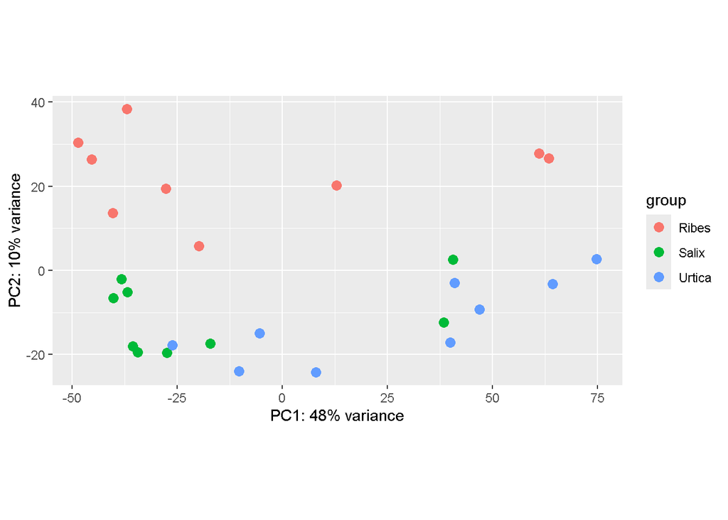

```r
# PCA plot
plotPCA(Pcal_vst, intgroup=c("condition"), ntop = 1000)
```

```
## using ntop=1000 top features by variance
```

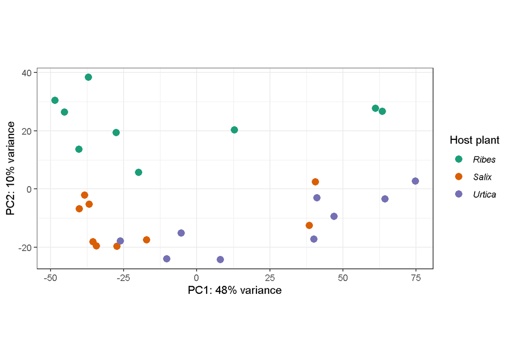

```r
# plotPCA depends on ggplot2, so we can spice it up a bit:
plotPCA(Pcal_vst, intgroup=c("condition"), ntop = 1000) +
  theme_bw() +
  scale_color_brewer(palette = "Dark2", name = "Host plant") +
  theme(legend.text = element_text(face = "italic"))
```

```r
# save your plot
ggsave("output/Pcal_vst_PC1_PC2.pdf", height = 6, width = 6)
```

If you want to use another PCA package for visualization you can get the transformed data `assay(Pcal_vst)`like so.

For the hierarchical clustering we need to calculate the distance between the samples. I imagine this works like calculating distance for phylogenies from sequences. Where you see the pairwise differences and then make a simple phylogeny based on that.

We first collect the data with `assay(Pcal_vst)` then we transpose using `t()` because the next function we use `dist()` works on rows.Then we need it as a matrix too.

```r
Pcal_vst_dists <- dist(t(assay(Pcal_vst)))
Pcal_vst_mat <- as.matrix(Pcal_vst_dists)
```

Then simply run `hclust()`

```r
Pcal_vst_hc <- hclust(Pcal_vst_dists)
```

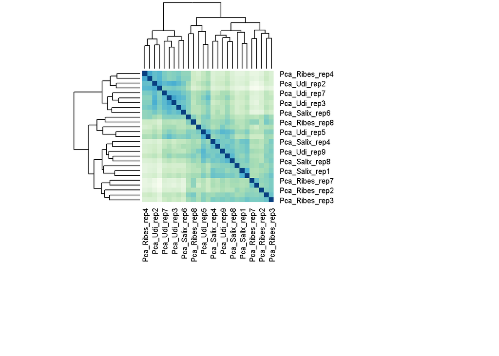

```r
# create a color palette
hmcol <- colorRampPalette(brewer.pal(9, "GnBu"))(100)

# Plot the heatmap
Pcal_hm <- heatmap(Pcal_vst_mat,
        Rowv=as.dendrogram(Pcal_vst_hc),
        symm=TRUE,
        col = rev(hmcol),
        margin=c(13, 13),
        cexRow = 0.75,
        cexCol = 0.75)
```

We can then simply save the results in a pdf file by first creating one and finishing it off with `dev.off()`.

```r
pdf(file = "output/Pcal_vst_sampleHeatmap.pdf", height = 6, width = 6)
heatmap(Pcal_vst_mat,
        Rowv=as.dendrogram(Pcal_vst_hc),
        symm=TRUE,
        col = rev(hmcol),
        margin=c(13, 13),
        cexRow = 0.75,
        cexCol = 0.75)
dev.off()
```

In this plot darker is more similar gene expression.

## Lets create a PCA biplot

First we set `ntop=1000`, so it is recognizable where we set our upper limit.We calculate the variance of the expression per gene and order the genes that are most different and put their names in a vector. After we only take the columns containing the names from the main dataset and transpose, because this package works on rows.

```r
ntop = 1000

Pcal_vst_mat <- assay(Pcal_vst)
Pcal_vst_ntop_names <-names(sort(apply(Pcal_vst_mat, 1, var), decreasing = T))[1:ntop]
Pcal_vst_ntop <- t(Pcal_vst_mat[Pcal_vst_ntop_names,])
```

Then we simlpy calculate the PC’s with `prcomp()` and we use the summary to see if it the same as our earlier PCA.

```r
# calculate principal components
Pcal_vst_pca <- prcomp(Pcal_vst_ntop)

# make sure they match the PCA you made with plotPCA by looking at the summary of the PCA object. Does the proportion of the variance explained by PC1 match the % on the x axis from earlier?
summary(Pcal_vst_pca)
```

```
## Importance of components:
##                            PC1     PC2      PC3      PC4      PC5      PC6
## Standard deviation     40.9428 18.9342 16.09926 13.16878 11.87422 11.08549
## Proportion of Variance  0.4765  0.1019  0.07368  0.04929  0.04008  0.03493
## Cumulative Proportion   0.4765  0.5784  0.65208  0.70138  0.74146  0.77639
##                             PC7     PC8     PC9    PC10   PC11    PC12    PC13
## Standard deviation     10.17571 9.22388 8.87894 7.77219 7.2642 6.99598 6.63737
## Proportion of Variance  0.02943 0.02418 0.02241 0.01717 0.0150 0.01391 0.01252
## Cumulative Proportion   0.80582 0.83001 0.85242 0.86959 0.8846 0.89850 0.91102
##                           PC14    PC15    PC16    PC17    PC18    PC19    PC20
## Standard deviation     6.00701 5.86797 5.57806 5.48883 5.26300 4.97007 4.64101
## Proportion of Variance 0.01026 0.00979 0.00884 0.00856 0.00787 0.00702 0.00612
## Cumulative Proportion  0.92128 0.93107 0.93991 0.94848 0.95635 0.96337 0.96949
##                           PC21    PC22    PC23    PC24    PC25    PC26
## Standard deviation     4.62452 4.50697 4.36151 4.12727 3.96423 3.72109
## Proportion of Variance 0.00608 0.00577 0.00541 0.00484 0.00447 0.00394
## Cumulative Proportion  0.97557 0.98135 0.98675 0.99160 0.99606 1.00000
##                             PC27
## Standard deviation     1.818e-14
## Proportion of Variance 0.000e+00
## Cumulative Proportion  1.000e+00
```

We take the variance explained in the first to PCs from the summary

```r
pc1_prop <- summary(Pcal_vst_pca)$importance[2,1]
pc2_prop <- summary(Pcal_vst_pca)$importance[2,2]
```

We want to create a data frame of principal component values for each sample. They are in column x of Pcal_vst_pca. We need to change our rownames back to real columns for joining with dplyr. Then we join it to the sample data columns sampleName, condition and family using `left_join`. This will get the column on the left side of the data frame.

```r
Pcal_vst_pca_df <- as.data.frame(Pcal_vst_pca$x) %>%
  rownames_to_column(var = "sampleName") %>%
  left_join(dplyr::select(Pcal_sampledata, sampleName, condition, family))
```

Now we want to create the loadings of the top 10 most variable genes

```r
Pcal_vst_pca_loadings <- as.data.frame(Pcal_vst_pca$rotation[Pcal_vst_ntop_names,])%>%
  rownames_to_column(var = "geneID") %>%
  head(10)
```

Now we can visualize with two ggplot geom thingies. Most importantly we scale the loadings by 200 to make them visible for the rest we also do a lot of other fancy ggplot stuff.

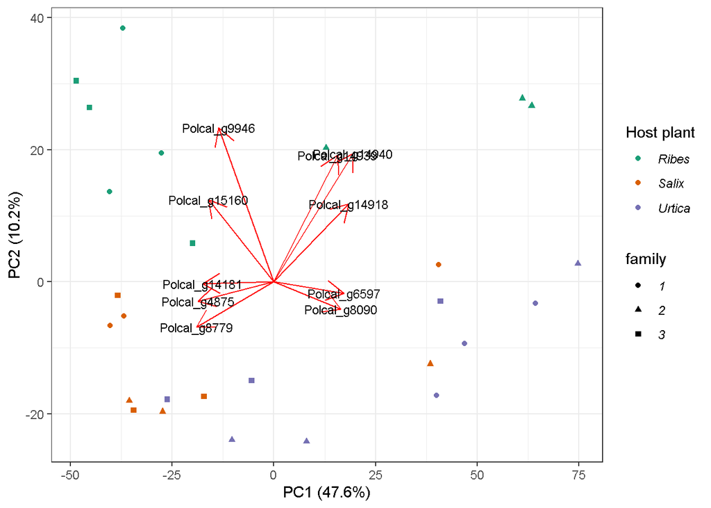

```r
ggplot() +
  geom_point(data = Pcal_vst_pca_df,
             aes(x = PC1, y = PC2, color = condition, shape = family)) +
  geom_segment(data = Pcal_vst_pca_loadings,
               aes(x=0, y=0, xend=PC1*200, yend=PC2*200),
               arrow = arrow(length=unit(0.5, 'cm')), color = "red") +
  annotate(geom = "text",
           label = Pcal_vst_pca_loadings$geneID,
           x = Pcal_vst_pca_loadings$PC1*200, y = Pcal_vst_pca_loadings$PC2*200,
           size = 3)+
  theme_bw() +
  labs( x = paste0("PC1 (", signif(pc1_prop*100,3), "%)"),
        y = paste0("PC2 (", signif(pc2_prop*100,3), "%)")) +
  scale_color_brewer(palette = "Dark2", name = "Host plant") +
  theme(legend.text = element_text(face = "italic"))
```

Lets put that in a pdf too

```r
pdf(file = "output/Pcal_vst_PC1_PC2_biplot.pdf", height = 6, width = 6)
ggplot() +
  geom_point(data = Pcal_vst_pca_df,
             aes(x = PC1, y = PC2, color = condition, shape = family)) +
  geom_segment(data = Pcal_vst_pca_loadings,
               aes(x=0, y=0, xend=PC1*200, yend=PC2*200),
               arrow = arrow(length=unit(0.5, 'cm')), color = "red") +
  annotate(geom = "text",
           label = Pcal_vst_pca_loadings$geneID,
           x = Pcal_vst_pca_loadings$PC1*200, y = Pcal_vst_pca_loadings$PC2*200,
           size = 3)+
  theme_bw() +
  labs( x = paste0("PC1 (", signif(pc1_prop*100,3), "%)"),
        y = paste0("PC2 (", signif(pc2_prop*100,3), "%)")) +
  scale_color_brewer(palette = "Dark2", name = "Host plant") +
  theme(legend.text = element_text(face = "italic"))

dev.off()
```

You can also do a multidimensional scaling plot. That might have some advantages over a PCA. Didn’t look into this one.

```r
library(vegan)
ntop = 1000

Pcal_vst_mat <- assay(Pcal_vst)
Pcal_vst_ntop_names <-names(sort(apply(Pcal_vst_mat, 1, var), decreasing = T))[1:ntop]
Pcal_vst_ntop <- t(Pcal_vst_mat[Pcal_vst_ntop_names,])

Pcal_vst_ntop_dist <- vegdist(Pcal_vst_ntop)
Pcal_vst_ntop_mds <- monoMDS(Pcal_vst_ntop_dist, model = "loc")
Pcal_vst_ntop_mds_df <- Pcal_vst_ntop_mds$points %>%
  as.data.frame() %>%
  rownames_to_column("sampleName") %>%
  left_join(Pcal_sampledata)
```

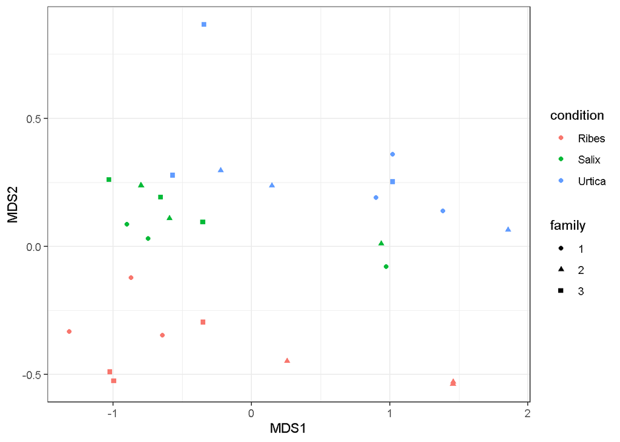

```r
ggplot(Pcal_vst_ntop_mds_df, aes(x = MDS1, y = MDS2) ) +
  geom_point(aes(color = condition, shape = family)) +
  theme_bw()
```

```r
pdf(file = "output/Pcal_vst_MDS.pdf", height = 6, width = 6)
ggplot(Pcal_vst_ntop_mds_df, aes(x = MDS1, y = MDS2) ) +
  geom_point(aes(color = condition, shape = family)) +
  theme_bw()
dev.off()
```

# Differential gene expression anaylis

The function DESeq2 performs the normalization of the counts using the size factors, estimates dispersion, and fits the linear model. By overwriting the old Pcal_dds variable we can add the new calculated values to out earlier created `DESeqDataSet`.

```r
Pcal_dds <- DESeq(Pcal_dds)
```

```
## -- replacing outliers and refitting for 46 genes
## -- DESeq argument 'minReplicatesForReplace' = 7
## -- original counts are preserved in counts(dds)
```

The *Wald test* is often used for hypothesis testing with groups. In `DESeq2` we provide groups with contrast. Lest see what contrast are possible in our design

```r
resultsNames(Pcal_dds)
```

```
## [1] "Intercept"                 "condition_Salix_vs_Ribes"
## [3] "condition_Urtica_vs_Ribes"
```

Lets test Urtica vs Ribes. We can give the the contrast in a vector to the `results`function in DESeq2. Or name the contrast.

```r
# specify the contrast by naming the factor you want to test
# and the levels of the factor you want to compare.
contrast_U_R <- c("condition", "Urtica", "Ribes")

# extract the results for your specified contrast
Pcal_res_table_U_R <- results(Pcal_dds, contrast=contrast_U_R)

# this can alternatively be written using the names of the contrasts
#Pcal_res_table_U_R <- results(Pcal_dds, name = "condition_Urtica_vs_Ribes") # do not run this code, the results are the same as the previous line
```

The Wald test calculates how likely it is that the difference in gene expression would occur randomly. The false discovery adjusted (Benjamini-Hochberg (BH)) p values for this test are stored in the padj column.

```r
# sort results based on the padj
Pcal_res_table_U_R <- Pcal_res_table_U_R[order(Pcal_res_table_U_R$padj),]

# You will now have the smallest padj values at the top of your table
head(Pcal_res_table_U_R)
```

```
## log2 fold change (MLE): condition Urtica vs Ribes
## Wald test p-value: condition Urtica vs Ribes
## DataFrame with 6 rows and 6 columns
##                baseMean log2FoldChange     lfcSE      stat      pvalue
##               <numeric>      <numeric> <numeric> <numeric>   <numeric>
## Polcal_g14648   151.940       -7.88689  0.640657  -12.3106 7.93965e-35
## Polcal_g13164  1257.501       -4.43612  0.363695  -12.1973 3.21147e-34
## Polcal_g15160 22471.814       -8.32706  0.687415  -12.1136 8.94943e-34
## Polcal_g15180  1752.909       -6.49663  0.549749  -11.8174 3.17242e-32
## Polcal_g3216   2089.317       -5.39255  0.464031  -11.6211 3.21931e-31
## Polcal_g13159   565.331       -5.65883  0.529762  -10.6818 1.23799e-26
##                      padj
##                 <numeric>
## Polcal_g14648 7.45056e-31
## Polcal_g13164 1.50682e-30
## Polcal_g15160 2.79938e-30
## Polcal_g15180 7.44249e-29
## Polcal_g3216  6.04201e-28
## Polcal_g13159 1.93622e-23
```

```r
# save your results
write_tsv(as.data.frame(Pcal_res_table_U_R), "output/Pcal_res_table_U_R.tsv")
```

The column headers are:

- baseMean: mean of normalized counts for all samples
- log2FoldChange: log2 fold change or LFC
- lfcSE: standard error of log2 fold change
- stat: the Wald test statistic
- pval: Wald test p-value
- padj: Benjamini-Hochberg (BH) adjusted p-values

What is the gene with the lowest P-value?

```r
head(Pcal_res_table_U_R)
```

```
## log2 fold change (MLE): condition Urtica vs Ribes
## Wald test p-value: condition Urtica vs Ribes
## DataFrame with 6 rows and 6 columns
##                baseMean log2FoldChange     lfcSE      stat      pvalue
##               <numeric>      <numeric> <numeric> <numeric>   <numeric>
## Polcal_g14648   151.940       -7.88689  0.640657  -12.3106 7.93965e-35
## Polcal_g13164  1257.501       -4.43612  0.363695  -12.1973 3.21147e-34
## Polcal_g15160 22471.814       -8.32706  0.687415  -12.1136 8.94943e-34
## Polcal_g15180  1752.909       -6.49663  0.549749  -11.8174 3.17242e-32
## Polcal_g3216   2089.317       -5.39255  0.464031  -11.6211 3.21931e-31
## Polcal_g13159   565.331       -5.65883  0.529762  -10.6818 1.23799e-26
##                      padj
##                 <numeric>
## Polcal_g14648 7.45056e-31
## Polcal_g13164 1.50682e-30
## Polcal_g15160 2.79938e-30
## Polcal_g15180 7.44249e-29
## Polcal_g3216  6.04201e-28
## Polcal_g13159 1.93622e-23
```

To make it easier to see what is up-regulated in what host plant caterpillar we can plot it.

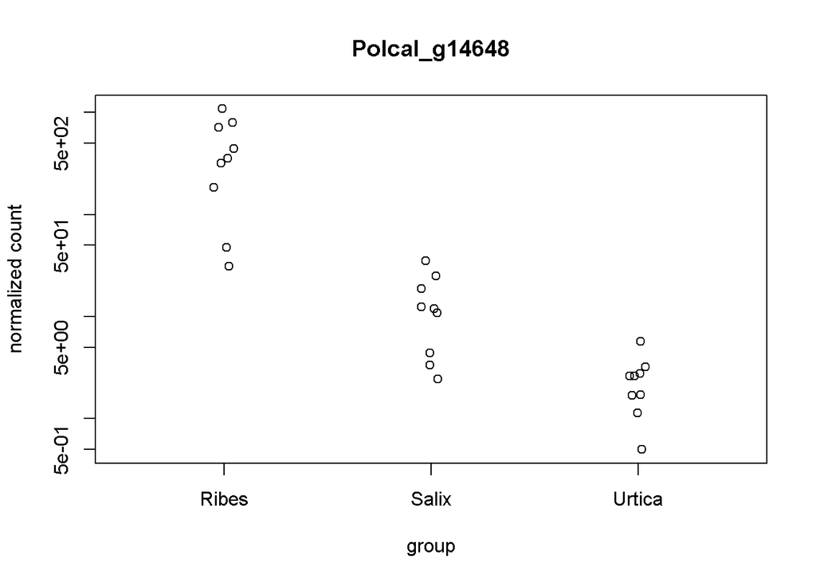

```r
plotCounts(Pcal_dds, gene="Polcal_g14648", intgroup="condition")
```

We can see it is up-regulated in Ribes. The LFC (log2FoldChange) is negative. This shows that when the LFC is negative it is lower in Urtica compared to Ribes.

When specifying the contrast `c("condition", "Urtica", "Ribes")` you are really asking the question `How does Urtica (condition 1) differ relative to Ribes (condition 2), which should help when trying to specify your own contrasts.

Now we can plot using `plotMA()`.

[figure not shown]

```r
plotMA(
  Pcal_dds,
  alpha = 0.01,
  ylim=c(-2,2),
  main = "Differential gene expresion Ribes vs Urtica",
  xlab = "mean of normalized counts",
  colNonSig = "gray60",
  colSig = "red4",
  colLine = "grey40",
  returnData = FALSE,
  MLE = FALSE
)
```

You can do it with ggplot too, but you need a data frame

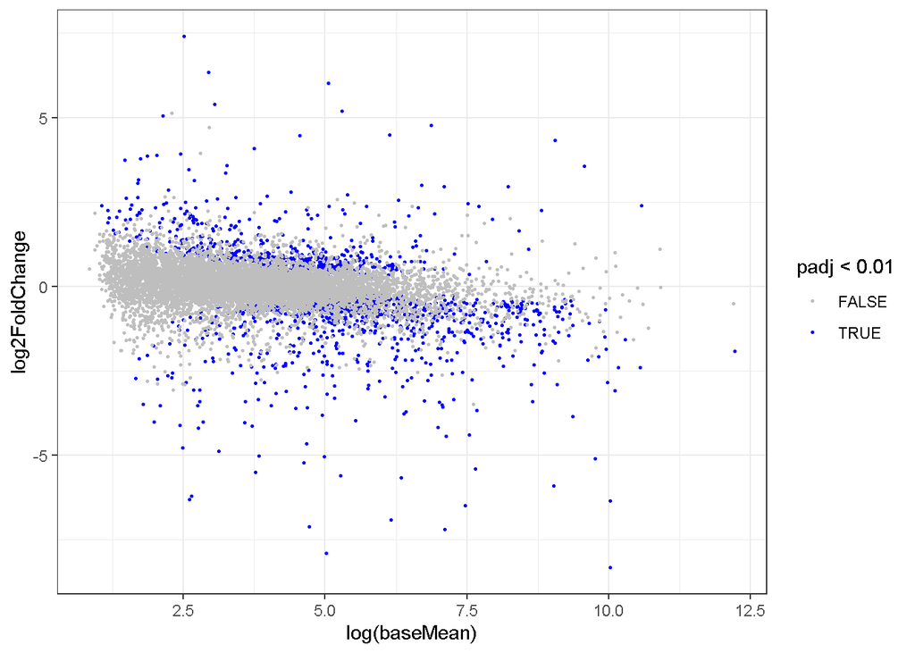

```r
ggplot(as.data.frame(Pcal_res_table_U_R), aes(x = log(baseMean), y = log2FoldChange)) +
  geom_point(aes(color = padj < 0.01), size = 0.5) +
  scale_color_manual(values = c("grey", "blue"))+
  theme_bw()
```

Save the graph

```r
ggsave("output/Pcal_MAplot_U_R.pdf", height = 6, width = 6)
```

Normally, we expect to see significant fold changes across the range of expression levels.

If there is a lot of variation in expression counts within groups then even genes with high LFC values can insignificant, look at grey dots with high LFC. Then they likely have low counts and are not significant because of it. Using DESeq2, there is a way to shrink the log2 fold change for genes with low counts so that you can have more confidence in the fold change estimates. **Should I do this, is them being insignificant not enough?**

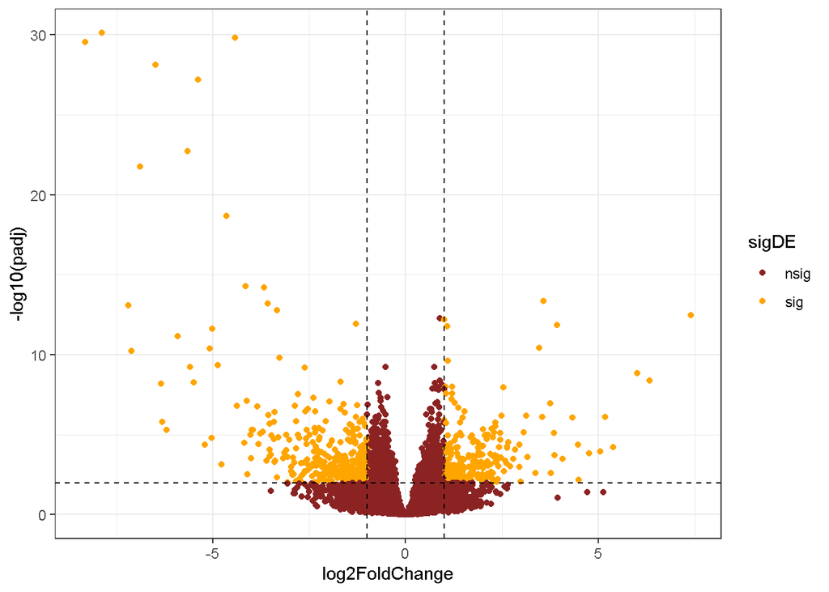

```r
Pcal_res_df_U_R <- Pcal_res_table_U_R %>%
  as.data.frame() %>%
  mutate(sigDE = if_else(padj < 0.01 & abs(log2FoldChange) > 1 , "sig", "nsig"))

ggplot(as.data.frame(Pcal_res_df_U_R), aes(x = log2FoldChange, y = -log10(padj))) +
 geom_point(aes(color = sigDE)) +
  scale_color_manual(values = c("brown4", "orange"))+
  geom_hline(yintercept = -log10(0.01), linetype = "dashed")+
  geom_vline(xintercept = c(-1, 1), linetype = "dashed") +
  theme_bw()
```

```r
ggsave("output/Pcal_volcanoPlot_U_R.pdf", height = 6, width = 6)
```

Save it

Darker red and darker blue is higher and lower expression in this case.

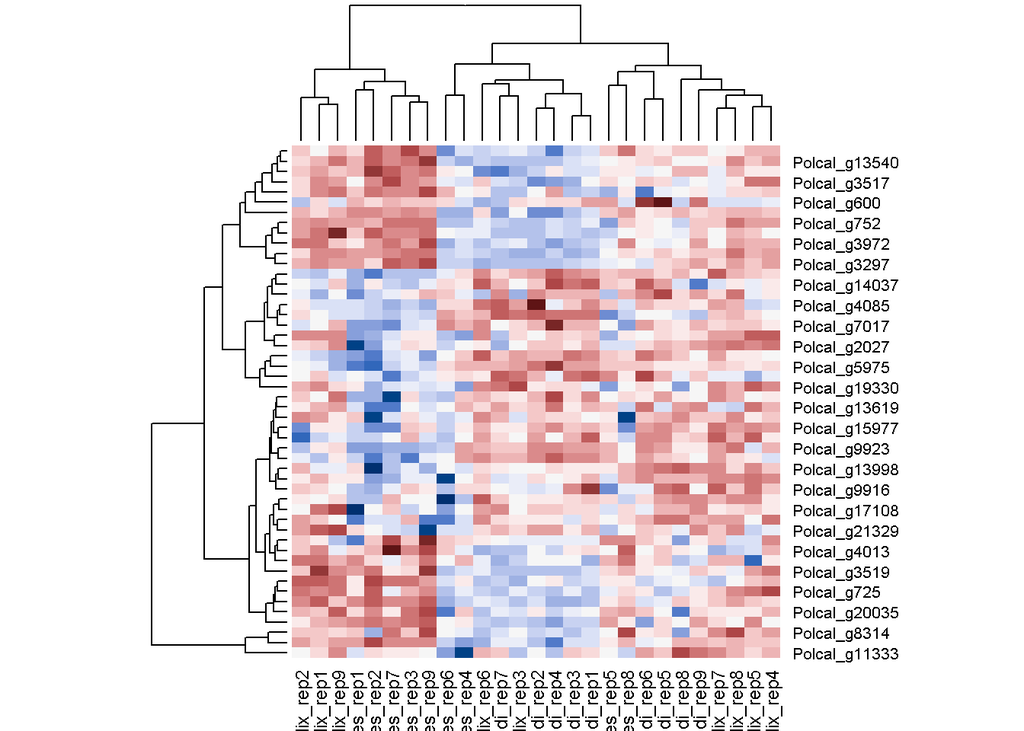

```r
DE_genes_df <- Pcal_res_table_U_R |>
  as.data.frame() |>
  rownames_to_column("geneID") |>
  filter(abs(log2FoldChange) > 1) |>
  filter(padj > 0.01)

DE_genes_top50 <- DE_genes_df$geneID %>%
  head(50)

Pcal_vst_DE_top50_U_R <- assay(Pcal_vst)[rownames(Pcal_vst) %in% DE_genes_top50,]

heatmap(Pcal_vst_DE_top50_U_R,
        margin = c(3,4), col = hcl.colors(25, palette = "Blue Red 3"))
```

```r
pdf(file = "output/Pcal_geneHeatmap_U_R.pdf", height = 9, width = 12)
heatmap(Pcal_vst_DE_top50_U_R,
        margin = c(3,4), col = hcl.colors(25, palette = "Blue Red 3"))
dev.off()
```

Identify sub-groups of differentially.

```r
Pcal_vst_DE_U_R <- assay(Pcal_vst)[rownames(Pcal_vst) %in% DE_genes_df$geneID,]
```

We will use `Mfuzz`. To use it we need a different matrix format called an `ExpressionSet`. We need to create a new temporary file to load it as that.

```r
library(Mfuzz)
tmp <- tempfile()
write.table(Pcal_vst_DE_U_R,file=tmp, sep='\t', quote = F, col.names=NA)

#read it back in as an expression set
dat <- table2eset(file=tmp)
```

Fuzzy works best when the data is not transformed and the mean is scaled to 0.

```r
dat.s <- standardise(dat)

# you can remove the unscaled expressionSet
rm(dat)
```

Fuzzy c-means is better suited for us as it does not assign genes to cluster if they are in between cluster and thus they want skew the cluster because they look slightly more than the others.

```r
m1 <- mestimate(dat.s)
m1
```

```
## [1] 1.109573
```

We want the lowest distance to the centroid, for up to 22 clusters with steps of 1 starting at 2. Then we store this number of clusters in a vector. **3?**

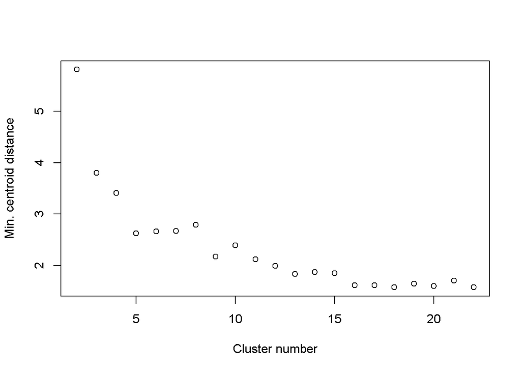

```
##  [1] 5.810408 3.796658 3.409012 2.625174 2.663595 2.669518 2.788563 2.173010
##  [9] 2.391029 2.121700 1.991584 1.832696 1.871393 1.850820 1.614521 1.614002
## [17] 1.574613 1.645169 1.600029 1.704874 1.574558
```

```r
Dmin(dat.s, m=m1, crange=seq(2,22,1), repeats=3, visu=TRUE)
```

```r
# store the value of the inflection point as an object. we will use this in the fuzzy clustering function below.
c_estimate <- 3
```

Then we run fuzzy using the vectors we created.

```r
Pcal_DE_U_R_fcm_results <- mfuzz(dat.s,centers=c_estimate,m=m1)
```

This is then very easy to plot using the original `ExpressionSet` and the results.

```r
mfuzz.plot2(dat.s, Pcal_DE_U_R_fcm_results)
```

Or use ggplot to make it look nicer. **Don’t know exactly how to read these.**

```r
#get the centroids into a long dataframe:
Pcal_DE_U_R_fcm_centroids <- Pcal_DE_U_R_fcm_results$centers
Pcal_DE_U_R_fcm_centroids_df <- data.frame(Pcal_DE_U_R_fcm_centroids)
Pcal_DE_U_R_fcm_centroids_df$cluster <- row.names(Pcal_DE_U_R_fcm_centroids_df)

Pcal_DE_U_R_centroids_long <- tidyr::pivot_longer(Pcal_DE_U_R_fcm_centroids_df,
                                      names_to = "sampleName",
                                      values_to = 'value', -cluster) %>%
  left_join(dplyr::select(Pcal_sampledata, sampleName, condition))
```

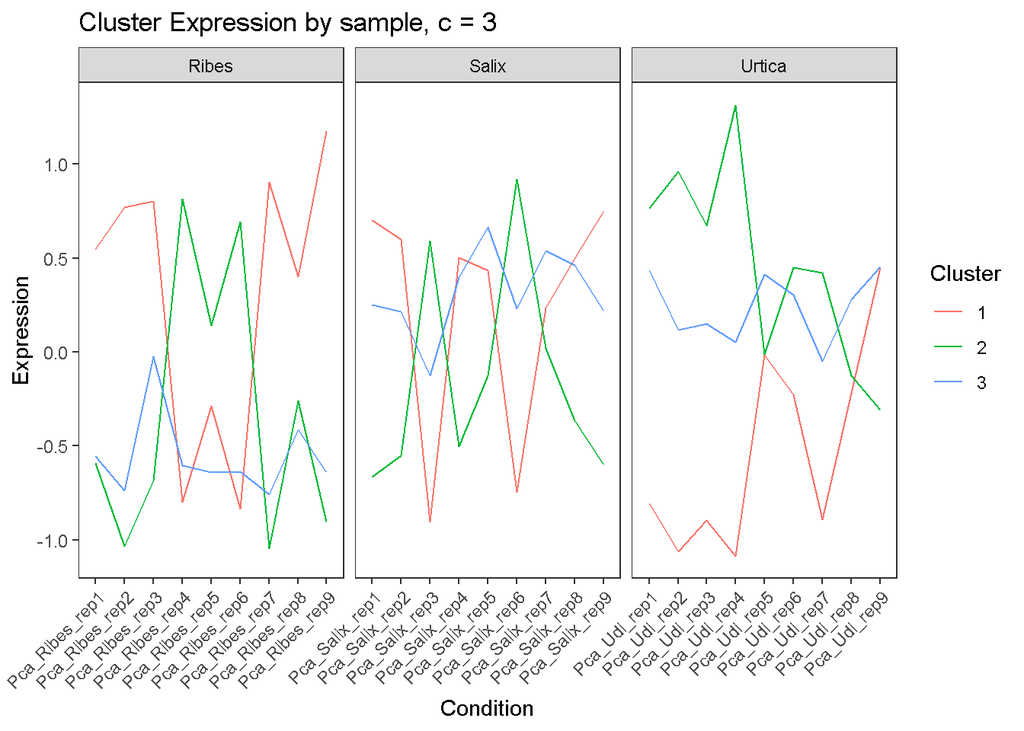

```r
ggplot(Pcal_DE_U_R_centroids_long,
       aes(x=sampleName,y=value, group=cluster, color=as.factor(cluster))) +
  geom_line() +
  xlab("Condition") +
  ylab("Expression") +
  labs(title=paste0("Cluster Expression by sample, c = ",c_estimate),color = "Cluster")+
  theme_bw()+
  facet_grid(~condition, scales = "free_x", space = "free_x")+
  theme(panel.grid = element_blank(),
        axis.text.x = element_text(angle = 45, hjust = 1))
```

```r
ggsave("output/Pcal_sub_group_fuzz_U_R.pdf", height = 6, width = 6)
```

Extract the genes from the soft cores. `acore()` is a function from mfuzz that extracts the genes from soft clusters

```r
Pcal_DE_U_R_acore <- acore(dat.s,Pcal_DE_U_R_fcm_results,min.acore=0)
Pcal_DE_U_R_acore_df <- do.call(rbind, lapply(seq_along(Pcal_DE_U_R_acore), function(i){ data.frame(CLUSTER=i, Pcal_DE_U_R_acore[[i]])}))
```

## GO-terms

You can get the you can get the functional annotation using EggNOG-mapper (http://eggnog-mapper.embl.de/). Here it was already done. Load them. We will also create a path to the file.

```r
GO_annotation <- read_tsv("Pcal_GO_annotation.tsv", col_names = c("gene_id", "GOterms"))
GO_path <- "Pcal_GO_annotation.tsv"

head(GO_annotation)
```

```
## # A tibble: 6 × 2
##   gene_id    GOterms
##   <chr>      <chr>
## 1 Polcal_g1  -
## 2 Polcal_g6  -
## 3 Polcal_g7  -
## 4 Polcal_g8  -
## 5 Polcal_g10 GO:0005575,GO:0005622,GO:0005623,GO:0005737,GO:0005783,GO:0012505,…
## 6 Polcal_g11 GO:0000003,GO:0000226,GO:0000375,GO:0000377,GO:0000398,GO:0001578,…
```

From not model species not all genes will have an annotated function. We should keep this in mind. Here we grep from the column GOterms and sum them to see how many of the genes are annotated.

```r
grepl(GO_annotation$GOterms, pattern ="GO") %>% sum()
```

```
## [1] 7687
```

We will use the topGO package here.

```r
# here I will be only analyzing GO terms with at least 5 members,
# as this yield more stable results.
node_size= 5

# We will focus on Biological process terms (BP)
GO_category="BP"

# use topGO to read the functional annotation
geneID2GO <- readMappings(GO_path)

# define the gene universe
geneUniverse <- names(geneID2GO)
```

```r
up_U_R <- rownames(Pcal_res_table_U_R %>%
                           data.frame() %>%
                           filter(padj < 0.01 & log2FoldChange > 1))

write.csv(up_U_R, "up_U_R.csv", row.names = FALSE)

down_U_R <- rownames(Pcal_res_table_U_R %>%
                             data.frame() %>%
                             filter(padj < 0.01 & log2FoldChange < -1))

write.csv(down_U_R, "down_U_R.csv", row.names = FALSE)
```

“Generally, GSEA is best applied to an intermediately-sized gene set. Too small, it is unlikely that any GO term will occur often enough to be enriched. Instead, you can easily look at the genes themselves and make conclusions about their functions. Too large relative to the annotated gene universe and terms will occur in the list just as often as expected… because you’ve sampled all the genes!” Rachel

GSEA for down regulated stuff.

```r
genesOfInterest.bv <- down_U_R

geneList.bv <- factor(as.integer(geneUniverse %in% genesOfInterest.bv))
names(geneList.bv) <- geneUniverse

# Create a new topGO GSEA object
myGOdata.bv <- new("topGOdata",
                   description="Candidate genes",
                   ontology=GO_category,
                   allGenes=geneList.bv,
                   annot = annFUN.gene2GO,
                   gene2GO = geneID2GO,
                   nodeSize = node_size)
```

```
##
## Building most specific GOs .....
```

```
##  ( 13383 GO terms found. )
```

```
##
## Build GO DAG topology ..........
```

```
##  ( 13803 GO terms and 30804 relations. )
```

```
##
## Annotating nodes ...............
```

```
##  ( 7382 genes annotated to the GO terms. )
```

We run some statistical tests. We rely on the parent child version of the Fisher exact test as it will resolve the indipendence problem between the genes.

```r
# classic Fisher
resultClassic <- runTest(myGOdata.bv, algorithm="classic", statistic="fisher")
```

```
##
##           -- Classic Algorithm --
##
##       the algorithm is scoring 2507 nontrivial nodes
##       parameters:
##           test statistic: fisher
```

```r
# Fisher with parent-child algorithm
resultParentchild <- runTest(myGOdata.bv, algorithm="parentchild", statistic="fisher")
```

```
##
##           -- Parent-Child Algorithm --
##
##       the algorithm is scoring 2507 nontrivial nodes
##       parameters:
##           test statistic: fisher : joinFun = union
```

```
##
##   Level 14:  6 nodes to be scored.
```

```
##
##   Level 13:  24 nodes to be scored.
```

```
##
##   Level 12:  57 nodes to be scored.
```

```
##
##   Level 11:  121 nodes to be scored.
```

```
##
##   Level 10:  203 nodes to be scored.
```

```
##
##   Level 9:   294 nodes to be scored.
```

```
##
##   Level 8:   359 nodes to be scored.
```

```
##
##   Level 7:   405 nodes to be scored.
```

```
##
##   Level 6:   431 nodes to be scored.
```

```
##
##   Level 5:   322 nodes to be scored.
```

```
##
##   Level 4:   189 nodes to be scored.
```

```
##
##   Level 3:   79 nodes to be scored.
```

```
##
##   Level 2:   16 nodes to be scored.
```

Then we create a table with the results

```r
# GenTable() is  annoying and requires a number of terms we want reported (default is 10)
## so we leverage our topGOresult object
top_nodes <-  sum(resultParentchild@score < 0.05)

allRes_BP_down_U_R <- GenTable(myGOdata.bv,
                   classicFisher = resultClassic,
                   parentchildFisher = resultParentchild,
                   orderBy = "parentchildFisher",
                  topNodes = top_nodes)
```

The main purpose of the GO-terms is to identify which biological processes are being influenced by the differential gene expression.

```r
head(n = 20, allRes_BP_down_U_R)
```

```
##         GO.ID                                        Term Annotated Significant
## 1  GO:0055085                     transmembrane transport       841          51
## 2  GO:0044281            small molecule metabolic process      1272          67
## 3  GO:0055086 nucleobase-containing small molecule met...       563          39
## 4  GO:0006811                    monoatomic ion transport       843          52
## 5  GO:0072521 purine-containing compound metabolic pro...       462          35
## 6  GO:0006091 generation of precursor metabolites and ...       354          30
## 7  GO:0098754                              detoxification        73          14
## 8  GO:0006082              organic acid metabolic process       640          39
## 9  GO:0006753      nucleoside phosphate metabolic process       483          36
## 10 GO:0033572                       transferrin transport        19           7
## 11 GO:0072524 pyridine-containing compound metabolic p...        88          13
## 12 GO:1901135 carbohydrate derivative metabolic proces...       793          41
## 13 GO:1902600              proton transmembrane transport       110          25
## 14 GO:0019637           organophosphate metabolic process       712          37
```

[output cut: 27 more lines]

Visualize!

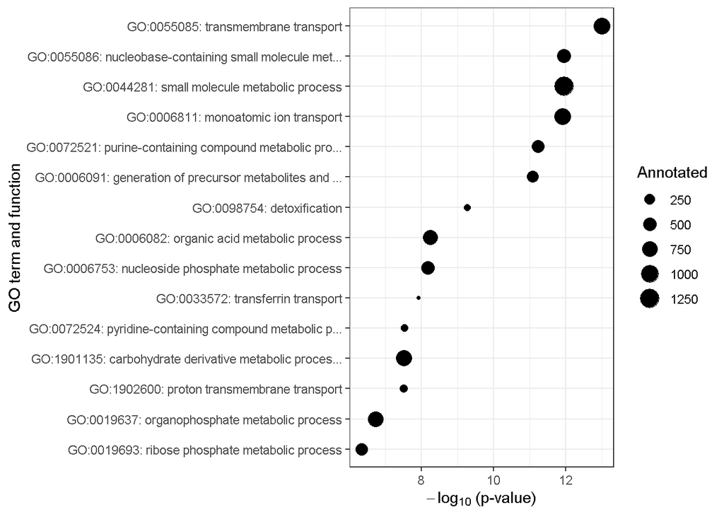

```r
# subset the results table
allRes_BP_down_U_R_top15 <- allRes_BP_down_U_R %>%
  mutate(GO.term = paste(GO.ID, Term, sep = ": "),
         parentchildFisher = as.numeric(parentchildFisher)) %>%
  arrange(parentchildFisher) %>%
  head(15)

# plot the subsetted results
# points are scaled by the tota number of genes that are annotated with each term term, which gives us an idea of how broad or specific a term is.

ggplot(allRes_BP_down_U_R_top15, aes(x = forcats::fct_reorder(GO.term, -log10(parentchildFisher)), GO.term, y = -log10(parentchildFisher) ))+
  geom_point(aes(size = Annotated)) +
  labs(x = "GO term and function", y = expression(-log[10]~"(p-value)")) +
  coord_flip() +
  theme_bw()
```

```r
# save your GO term plot

ggsave("output/allRes_BP_down_U_R_top15_dotplot.pdf")
```

We can see the most significant terms are have to do with the metabolic process. This makes sense as the larvea feed on different hostplants and different metabolic pathways are likely optimal.

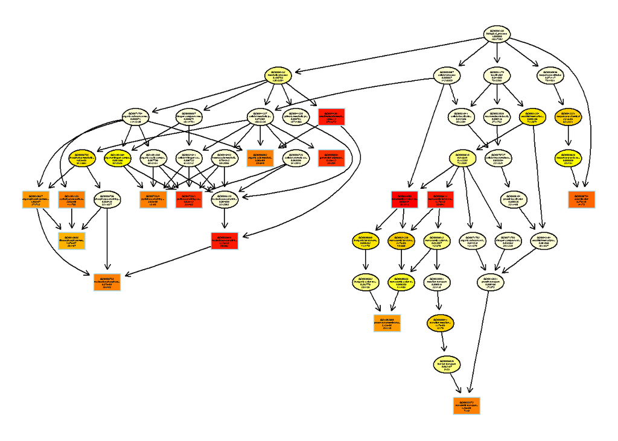

```
## $dag
## A graphNEL graph with directed edges
## Number of Nodes = 52
## Number of Edges = 84
##
## $complete.dag
## [1] "A graph with 52 nodes."
```

```r
showSigOfNodes(myGOdata.bv, score(resultParentchild), firstSigNodes = 15, useInfo = 'all')
```

```r
pdf(file = "output/Pcal_GO_parent_child_U_R.pdf")
showSigOfNodes(myGOdata.bv, score(resultParentchild), firstSigNodes = 15, useInfo = 'all')
```

```
## $dag
## A graphNEL graph with directed edges
## Number of Nodes = 52
## Number of Edges = 84
##
## $complete.dag
## [1] "A graph with 52 nodes."
```

```r
dev.off()
```

GSEA for up regulated stuff.

```r
genesOfInterest.bv <- up_U_R

geneList.bv <- factor(as.integer(geneUniverse %in% genesOfInterest.bv))
names(geneList.bv) <- geneUniverse

# Create a new topGO GSEA object
myGOdata.bv <- new("topGOdata",
                   description="Candidate genes",
                   ontology=GO_category,
                   allGenes=geneList.bv,
                   annot = annFUN.gene2GO,
                   gene2GO = geneID2GO,
                   nodeSize = node_size)
```

```
##
## Building most specific GOs .....
```

```
##  ( 13383 GO terms found. )
```

```
##
## Build GO DAG topology ..........
```

```
##  ( 13803 GO terms and 30804 relations. )
```

```
##
## Annotating nodes ...............
```

```
##  ( 7382 genes annotated to the GO terms. )
```

We run some statistical tests. We rely on the parent child version of the Fisher exact test as it will resolve the indipendence problem between the genes.

```r
# classic Fisher
resultClassic <- runTest(myGOdata.bv, algorithm="classic", statistic="fisher")
```

```
##
##           -- Classic Algorithm --
##
##       the algorithm is scoring 3782 nontrivial nodes
##       parameters:
##           test statistic: fisher
```

```r
# Fisher with parent-child algorithm
resultParentchild <- runTest(myGOdata.bv, algorithm="parentchild", statistic="fisher")
```

```
##
##           -- Parent-Child Algorithm --
##
##       the algorithm is scoring 3782 nontrivial nodes
##       parameters:
##           test statistic: fisher : joinFun = union
```

```
##
##   Level 17:  1 nodes to be scored.
```

```
##
##   Level 16:  8 nodes to be scored.
```

```
##
##   Level 15:  32 nodes to be scored.
```

```
##
##   Level 14:  37 nodes to be scored.
```

```
##
##   Level 13:  69 nodes to be scored.
```

```
##
##   Level 12:  126 nodes to be scored.
```

```
##
##   Level 11:  222 nodes to be scored.
```

```
##
##   Level 10:  340 nodes to be scored.
```

```
##
##   Level 9:   480 nodes to be scored.
```

```
##
##   Level 8:   591 nodes to be scored.
```

```
##
##   Level 7:   605 nodes to be scored.
```

```
##
##   Level 6:   549 nodes to be scored.
```

```
##
##   Level 5:   388 nodes to be scored.
```

```
##
##   Level 4:   224 nodes to be scored.
```

```
##
##   Level 3:   92 nodes to be scored.
```

```
##
##   Level 2:   17 nodes to be scored.
```

Then we create a table with the results

```r
# GenTable() is  annoying and requires a number of terms we want reported (default is 10)
## so we leverage our topGOresult object
top_nodes <-  sum(resultParentchild@score < 0.05)

allRes_BP_up_U_R <- GenTable(myGOdata.bv,
                   classicFisher = resultClassic,
                   parentchildFisher = resultParentchild,
                   orderBy = "parentchildFisher",
                  topNodes = top_nodes)
```

The main purpose of the GO-terms is to identify which biological processes are being influenced by the differential gene expression.

```r
head(n = 20, allRes_BP_up_U_R)
```

```
##         GO.ID                                        Term Annotated Significant
## 1  GO:0030029                actin filament-based process       505          35
## 2  GO:0048869              cellular developmental process      2607          82
## 3  GO:0007010                   cytoskeleton organization       908          38
## 4  GO:0010927 cellular component assembly involved in ...       178          22
## 5  GO:0051239 regulation of multicellular organismal p...      1841          66
## 6  GO:0055001                     muscle cell development       177          21
## 7  GO:0040011                                  locomotion      1347          50
## 8  GO:0008037                            cell recognition       174          16
## 9  GO:0007155                               cell adhesion       497          27
## 10 GO:0097435           supramolecular fiber organization       419          28
## 11 GO:0009653          anatomical structure morphogenesis      2152          78
## 12 GO:0030239                          myofibril assembly        88          17
## 13 GO:0003008                              system process      1151          49
## 14 GO:0032502                       developmental process      3993          98
```

[output cut: 27 more lines]

Visualize!

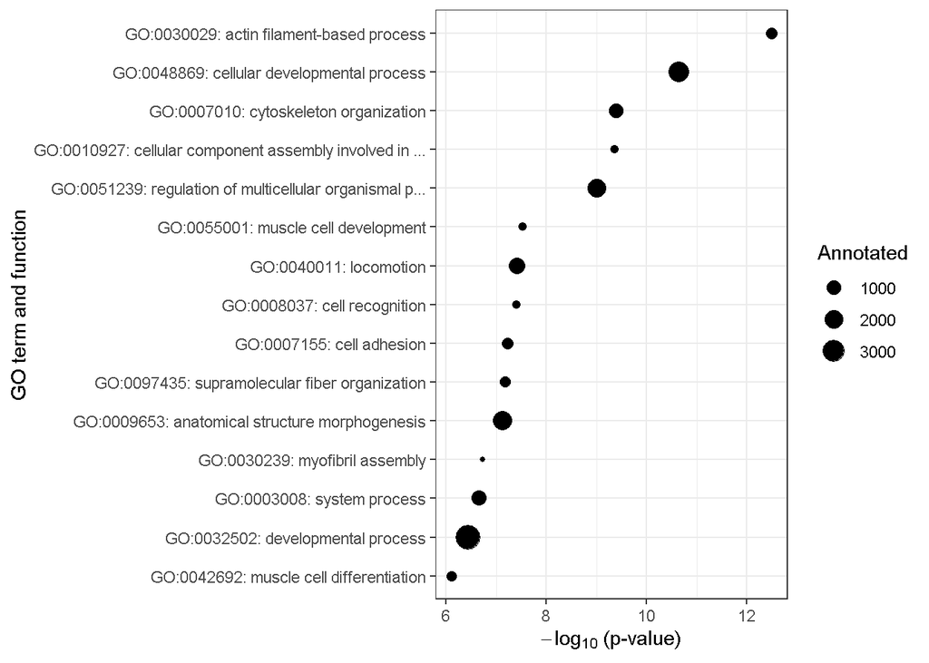

```r
# subset the results table
allRes_BP_up_U_R_top15 <- allRes_BP_up_U_R %>%
  mutate(GO.term = paste(GO.ID, Term, sep = ": "),
         parentchildFisher = as.numeric(parentchildFisher)) %>%
  arrange(parentchildFisher) %>%
  head(15)

# plot the subsetted results
# points are scaled by the tota number of genes that are annotated with each term term, which gives us an idea of how broad or specific a term is.

ggplot(allRes_BP_up_U_R_top15, aes(x = forcats::fct_reorder(GO.term, -log10(parentchildFisher)), GO.term, y = -log10(parentchildFisher) ))+
  geom_point(aes(size = Annotated)) +
  labs(x = "GO term and function", y = expression(-log[10]~"(p-value)")) +
  coord_flip() +
  theme_bw()
```

```r
# save your GO term plot

ggsave("output/allRes_BP_up_U_R_top15_dotplot.pdf")
```

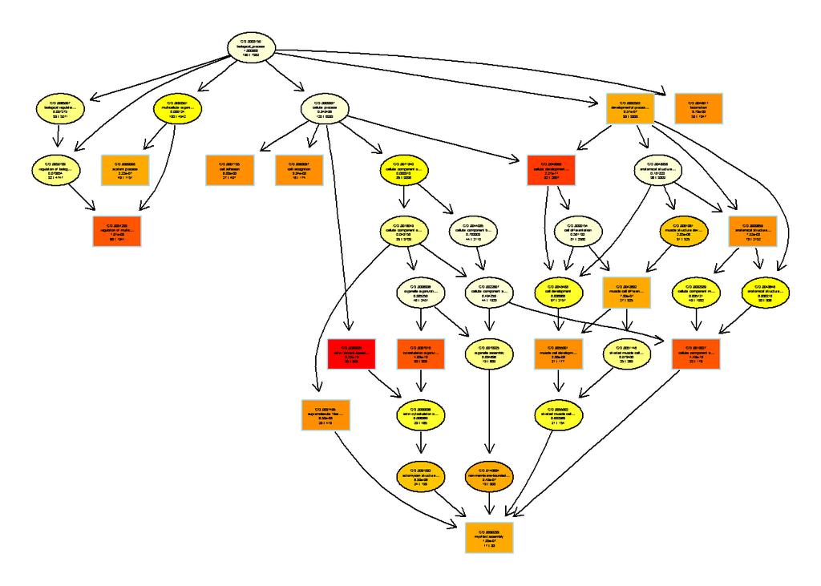

```
## $dag
## A graphNEL graph with directed edges
## Number of Nodes = 37
## Number of Edges = 55
##
## $complete.dag
## [1] "A graph with 37 nodes."
```

```r
showSigOfNodes(myGOdata.bv, score(resultParentchild), firstSigNodes = 15, useInfo = 'all')
```

```r
pdf(file = "output/Pcal_GO_parent_child_up_U_R.pdf")
showSigOfNodes(myGOdata.bv, score(resultParentchild), firstSigNodes = 15, useInfo = 'all')
```

```
## $dag
## A graphNEL graph with directed edges
## Number of Nodes = 37
## Number of Edges = 55
##
## $complete.dag
## [1] "A graph with 37 nodes."
```

```r
dev.off()
```

Mesmerize at the power of a for-loop. Here instead of doing it for biological processes we do it for molecular processes.

```r
# Starting with BP
GO_category="MF"

DEgenes_list <- list(down_U_R, up_U_R)
names(DEgenes_list) <- c("down_U_R", "up_U_R")

for (i in 1:2){
  # define candidate list
  genesOfInterest.bv <- DEgenes_list[[i]]

  # placing this within brackets causes all the lines to run in a single block
  # it can help you keep track of code that you usually run together

  geneList.bv <- factor(as.integer(geneUniverse %in% genesOfInterest.bv))
  names(geneList.bv) <- geneUniverse

  # Create a new topGO GSEA objected
  myGOdata.bv <- new("topGOdata",
                     description="Candidate genes",
                     ontology=GO_category,
                     allGenes=geneList.bv,
                     annot = annFUN.gene2GO,
                     gene2GO = geneID2GO,
                     nodeSize = node_size)

  # classic Fisher
  resultClassic <- runTest(myGOdata.bv, algorithm="classic", statistic="fisher")

  # Fisher with parent-child algorithm
  resultParentchild <- runTest(myGOdata.bv, algorithm="parentchild", statistic="fisher")
 top_nodes <-  sum(resultParentchild@score < 0.05)
  # Create a GSEA results table
  temp <- GenTable(myGOdata.bv,
                   classicFisher = resultClassic,
                   parentchildFisher = resultParentchild,
                   orderBy = "parentchildFisher",
                   topNodes = top_nodes)
  assign(paste0("allRes_MF_", names(DEgenes_list)[[i]]), temp)
}
```

```
##
## Building most specific GOs .....
```

```
##  ( 3247 GO terms found. )
```

```
##
## Build GO DAG topology ..........
```

```
##  ( 3312 GO terms and 4328 relations. )
```

```
##
## Annotating nodes ...............
```

```
##  ( 6505 genes annotated to the GO terms. )
```

```
##
##           -- Classic Algorithm --
##
##       the algorithm is scoring 406 nontrivial nodes
##       parameters:
##           test statistic: fisher
```

```
##
##           -- Parent-Child Algorithm --
##
##       the algorithm is scoring 406 nontrivial nodes
##       parameters:
##           test statistic: fisher : joinFun = union
```

```
##
##   Level 11:  2 nodes to be scored.
```

```
##
##   Level 10:  4 nodes to be scored.
```

```
##
##   Level 9:   16 nodes to be scored.
```

```
##
##   Level 8:   27 nodes to be scored.
```

```
##
##   Level 7:   55 nodes to be scored.
```

```
##
##   Level 6:   73 nodes to be scored.
```

```
##
##   Level 5:   90 nodes to be scored.
```

```
##
##   Level 4:   96 nodes to be scored.
```

```
##
##   Level 3:   32 nodes to be scored.
```

```
##
##   Level 2:   10 nodes to be scored.
```

```
##
## Building most specific GOs .....
```

```
##  ( 3247 GO terms found. )
```

```
##
## Build GO DAG topology ..........
```

```
##  ( 3312 GO terms and 4328 relations. )
```

```
##
## Annotating nodes ...............
```

```
##  ( 6505 genes annotated to the GO terms. )
```

```
##
##           -- Classic Algorithm --
##
##       the algorithm is scoring 472 nontrivial nodes
##       parameters:
##           test statistic: fisher
```

```
##
##           -- Parent-Child Algorithm --
##
##       the algorithm is scoring 472 nontrivial nodes
##       parameters:
##           test statistic: fisher : joinFun = union
```

```
##
##   Level 12:  1 nodes to be scored.
```

```
##
##   Level 11:  2 nodes to be scored.
```

```
##
##   Level 10:  6 nodes to be scored.
```

```
##
##   Level 9:   19 nodes to be scored.
```

```
##
##   Level 8:   32 nodes to be scored.
```

```
##
##   Level 7:   66 nodes to be scored.
```

```
##
##   Level 6:   80 nodes to be scored.
```

```
##
##   Level 5:   113 nodes to be scored.
```

```
##
##   Level 4:   97 nodes to be scored.
```

```
##
##   Level 3:   41 nodes to be scored.
```

```
##
##   Level 2:   14 nodes to be scored.
```

```r
head(allRes_MF_down_U_R)
```

```
##        GO.ID                                        Term Annotated Significant
## 1 GO:0005215                        transporter activity       754          46
## 2 GO:0016491                     oxidoreductase activity       445          41
## 3 GO:0003824                          catalytic activity      3040         106
## 4 GO:0015078 proton transmembrane transporter activit...        89          22
## 5 GO:0022853 active monoatomic ion transmembrane tran...       148          25
## 6 GO:0005385 zinc ion transmembrane transporter activ...        17           6
##   Expected Rank in parentchildFisher classicFisher parentchildFisher
## 1    17.15                         1       1.1e-10           1.1e-10
## 2    10.12                         2       2.1e-15           4.8e-10
## 3    69.17                         3       4.9e-10           4.9e-10
## 4     2.02                         4       1.6e-17           4.9e-07
## 5     3.37                         5       1.4e-15           2.4e-06
## 6     0.39                         6       1.3e-06           1.7e-05
```

```r
head(allRes_MF_up_U_R)
```

```
##        GO.ID                                        Term Annotated Significant
## 1 GO:0008092                cytoskeletal protein binding       497          32
## 2 GO:0042805                             actinin binding        17           7
## 3 GO:0050839              cell adhesion molecule binding       133          11
## 4 GO:0008307            structural constituent of muscle        33           6
## 5 GO:0019900                              kinase binding       471          19
## 6 GO:0022803 passive transmembrane transporter activi...       234          12
##   Expected Rank in parentchildFisher classicFisher parentchildFisher
## 1     9.17                         1       1.7e-10           8.3e-09
## 2     0.31                         2       1.0e-08           2.9e-05
## 3     2.45                         3       3.0e-05           0.00018
## 4     0.61                         4       2.6e-05           0.00047
## 5     8.69                         5       0.00092           0.00058
## 6     4.32                         6       0.00120           0.00070
```

Now we will rerun the analysis between salix and Urtica. This was not one of the options so we need to relevel

```r
# relevel condition
Pcal_dds$condition <- relevel(Pcal_dds$condition, "Salix")

# refit the model
Pcal_dds <- DESeq(Pcal_dds)
```

```
## found already estimated dispersions, replacing these
```

```
## -- replacing outliers and refitting for 46 genes
## -- DESeq argument 'minReplicatesForReplace' = 7
## -- original counts are preserved in counts(dds)
```

```r
# Check your work!
# Is the right contrast there?
resultsNames(Pcal_dds)
```

```
## [1] "Intercept"                 "condition_Ribes_vs_Salix"
## [3] "condition_Urtica_vs_Salix"
```

Now the Urtica vs Salix option should be visible.